# ASauk_Biol612_Homework2

Alexandra Sauk

2020-01-20

# Scenario 1

## A) Null and alternative hypotheses

Null hypthosis: There is no difference in the shrimp catches from 2009 and 2010.

Alternative hypothesis: There is a difference in the shrimp catches from 2009 and 2010.

## B) Histogram

```r
Shrimp_data=read.csv("ASauk_H2_Scenario1_data.csv")

library("reshape2")
library("ggplot2")
Sdf<-melt(Shrimp_data)
colnames(Sdf)<-c('Site','Year', 'Catch')
print(Sdf)
```

```
##    Site  Year  Catch
## 1     A Y2009  91900
## 2     B Y2009  95200
## 3     C Y2009  61900
## 4     D Y2009  73600
## 5     E Y2009 114300
## 6     F Y2009 117000
## 7     G Y2009 129500
## 8     H Y2009  74200
## 9     I Y2009 112700
## 10    J Y2009 152100
## 11    K Y2009  90700
## 12    L Y2009  89400
## 13    M Y2009 127500
## 14    N Y2009 142200
## 15    A Y2010  82900
## 16    B Y2010  86700
## 17    C Y2010  46900
## 18    D Y2010  41300
## 19    E Y2010  91600
## 20    F Y2010 100400
## 21    G Y2010 128400
## 22    H Y2010  55900
## 23    I Y2010 101700
## 24    J Y2010 139100
## 25    K Y2010  79300
## 26    L Y2010  76100
## 27    M Y2010 114100
## 28    N Y2010 139800
```

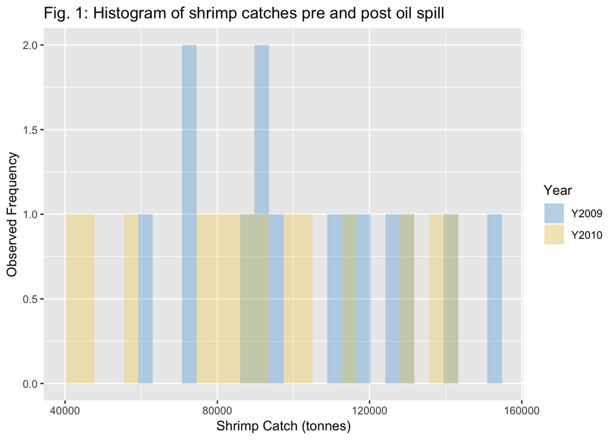

```r
Year<-Sdf$Year
Catch=Sdf$Catch

ggplot(Sdf, aes(x = Catch, fill=Year)) + geom_histogram(alpha = 0.3, position = 'identity') + labs(x = "Shrimp Catch (tonnes)", y ="Observed Frequency", title = "Fig. 1: Histogram of shrimp catches pre and post oil spill") + scale_color_manual(values=c("#3498DB","#F4D03F")) + scale_fill_manual(values=c("#3498DB","#F4D03F"))
```

```r
par(mar=c(8.5,6.5,4.1,3.1), mgp=c(3,1,0))

diff<-Shrimp_data$Y2010 - Shrimp_data$Y2009
diff
```

```
##  [1]  -9000  -8500 -15000 -32300 -22700 -16600  -1100 -18300 -11000 -13000
## [11] -11400 -13300 -13400  -2400
```

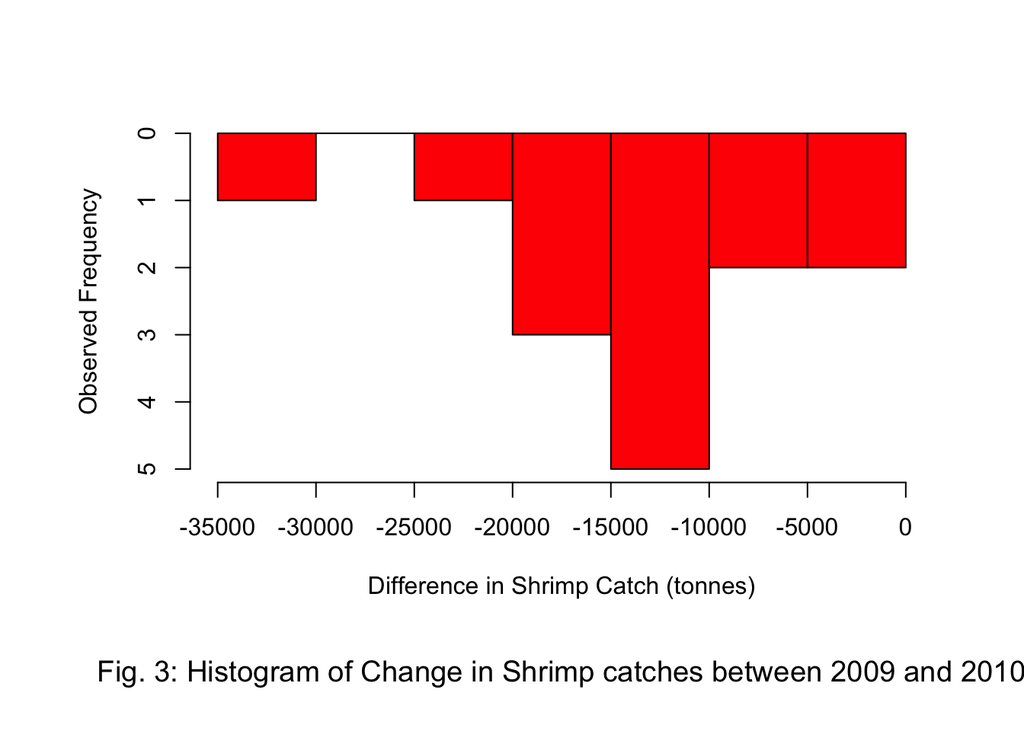

```r
hist(diff, xlab = "Difference in Shrimp Catch (tonnes)", ylab = "Observed Frequency", col = c("red"), main = NULL, ylim = c(5,0))
title(sub = "Fig. 3: Histogram of Change in Shrimp catches between 2009 and 2010", line=6, cex.sub=1.2)
```

## C) Hypothesis test

The data consists of shrimp catch values from 2009 and 2010 collected from the same villages such that the data is paired. A paired t-test should be used to compare the mean shrimp catches between the two years.

## D) Hypothesis test results

```r
t.test(Shrimp_data$Y2009, Shrimp_data$Y2010, paired = TRUE)
```

```
##
##  Paired t-test
##
## data:  Shrimp_data$Y2009 and Shrimp_data$Y2010
## t = 6.3808, df = 13, p-value = 2.415e-05
## alternative hypothesis: true difference in means is not equal to 0
## 95 percent confidence interval:
##   8882.005 17975.138
## sample estimates:
## mean of the differences
##                13428.57
```

```r
qt(0.975,13)
```

```
## [1] 2.160369
```

## E) Test statistic

The critical t-value for the paired t-test for this data is 2.16 and the observed t-test value is 6.38.

## F) Conclusion

In conclusion, the observed t-value is greater than the critical t-value and p<0.05 so we reject the null hypothesis. Thus, there is a statistically significant difference between the mean shrimp catch in 2009 and in 2010 such that there was a significant decrease in the shrimp catches after the oil spill.

# Scenario 2

## A) Null and alternative hypotheses

Null hypthosis: Phosphorous levels in Lake Erie are not different from the guideline level of 15 µg/L.

Alternative hypothesis: Phosphorous levels in Lake Erie are different from the guideline level of 15 µg/L.

## B) Histogram

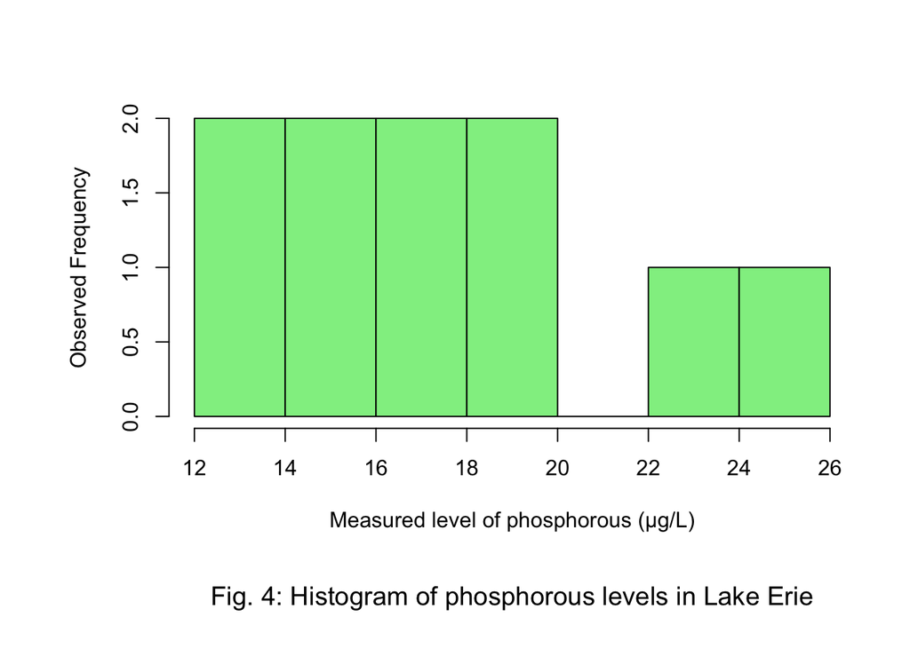

```r
Phosphorous_data=read.csv("ASauk_H2_Scenario2_data.csv")
par(mar=c(8.5,6.5,4.1,2.1), mgp=c(3,1,0))
hist(Phosphorous_data$Total.phosphorous, xlab = "Measured level of phosphorous (µg/L)", ylab = "Observed Frequency", col = c("light green"), main = NULL)
title(sub = "Fig. 4: Histogram of phosphorous levels in Lake Erie", line=6, cex.sub=1.2)
```

## C) Hypothesis test

The appropriate hypothesis test for this data is a one sample t-test as we are comparing observed data to a known value.

## D) Hypothesis test results

```r
t.test(Phosphorous_data$Total.phosphorous, mu=15)
```

```
##
##  One Sample t-test
##
## data:  Phosphorous_data$Total.phosphorous
## t = 1.8462, df = 9, p-value = 0.09794
## alternative hypothesis: true mean is not equal to 15
## 95 percent confidence interval:
##  14.47278 20.20722
## sample estimates:
## mean of x
##     17.34
```

```r
qt(0.975,9)
```

```
## [1] 2.262157
```

## E) Test statistic

The critical t-value for the one sample t-test for this data is 2.26 and the observed t-test value is 1.85.

## F) Conclusion

In conclusion, the observed t-value is less than the critical t-value and p>0.05 so we cannot reject the null hypothesis. Thus, there is no statistically significant difference between the mean phosphorous level in Lake Erie and the guideline level of phosphorous.

# Scenario 3

## A) Null and alternative hypotheses

Null hypthosis: The two diets, carnivrous and vegetaarian, do not differ in terms of growth rate for the farmed salmon.

Alternative hypothesis: The two diets, carnivrous and vegetaarian, do differ in terms of growth rate for the farmed salmon.

## B) Histogram

```r
library("reshape2")
library("ggplot2")

Carnivorous<-c(2.3,1.8,1.9,1.8,2.1,2.3,2,2.2,2.2,1.5,1.8,2.1,2.3,2.2,2.3)
Vegetarian<-c(1.6,1.1,0.7,1,1,0.8,1.2,0.8,0.9,0.6,0.7,0.6,0.8,0.8,1.1)
y_name<-'Growth.rate'
x_name<-'Diet'

df<-melt(data.frame(Carnivorous, Vegetarian))
colnames(df)<-c(x_name, y_name)
print(df)
```

```
##           Diet Growth.rate
## 1  Carnivorous         2.3
## 2  Carnivorous         1.8
## 3  Carnivorous         1.9
## 4  Carnivorous         1.8
## 5  Carnivorous         2.1
## 6  Carnivorous         2.3
## 7  Carnivorous         2.0
## 8  Carnivorous         2.2
## 9  Carnivorous         2.2
## 10 Carnivorous         1.5
## 11 Carnivorous         1.8
## 12 Carnivorous         2.1
## 13 Carnivorous         2.3
## 14 Carnivorous         2.2
```

[output cut: 16 more lines]

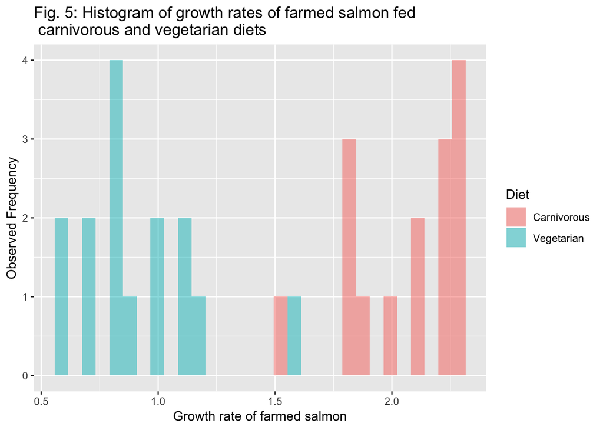

```r
Diet<-df$Diet
Growth.rate=df$Growth.rate
par(mar=c(8.5,6.5,4.1,4.1), mgp=c(3,1,0))
ggplot(df, aes(Growth.rate, fill = Diet)) + geom_histogram(alpha = 0.5) + labs(x = "Growth rate of farmed salmon", y ="Observed Frequency", title = "Fig. 5: Histogram of growth rates of farmed salmon fed \n carnivorous and vegetarian diets")
```

## C) Hypothesis test

The appropriate hypothesis test for this data is a two sample t-test as we are comparing two independent groups.

## D) Hypothesis test results

```r
t.test(Carnivorous, Vegetarian)
```

```
##
##  Welch Two Sample t-test
##
## data:  Carnivorous and Vegetarian
## t = 12.264, df = 27.834, p-value = 9.71e-13
## alternative hypothesis: true difference in means is not equal to 0
## 95 percent confidence interval:
##  0.9495322 1.3304678
## sample estimates:
## mean of x mean of y
## 2.0533333 0.9133333
```

```r
qt(0.975,27.834)
```

```
## [1] 2.048958
```

## F) Conclusion

In conclusion, the observed t-value is greater than the critical t-value and p<0.05 so we reject the null hypothesis. Thus, there is a statistically significant difference between the growth rates of farmed salmon fed carnivorous and those fed vegetarian diets.

# Scenario 4

## A) Null and alternative hypotheses

Null hypthosis: There is no difference in PCB poisoning between trophic levels.

Alternative hypothesis: There is a difference in PCB poisoning between trophic levels.

## B) Histogram

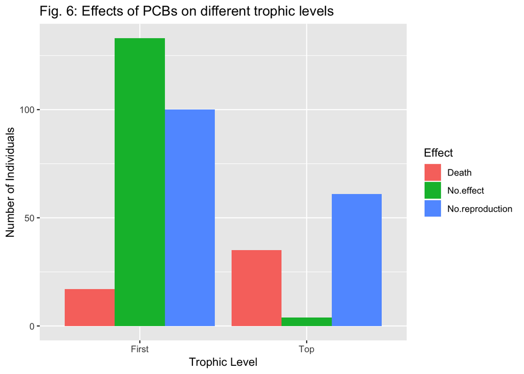

```r
PCB_data=read.csv("ASauk_Homework2_Scenario4_data2.csv")


library("ggplot2")

Effect<-PCB_data$Effect


ggplot(PCB_data, aes(x=PCB_data$Trophic.level, y=PCB_data$Individuals, fill = Effect))+geom_bar(stat="identity", position = position_dodge()) + labs(x = "Trophic Level", y = "Number of Individuals", title = "Fig. 6: Effects of PCBs on different trophic levels")
```

## C) Hypothesis test

The appropriate hypothesis test for this data is a chi-squared test.

## D) Hypothesis test results

```r
First<-c(133,100,17)
Top<-c(4,61,35)

dat=data.frame('First'=First, 'Top'=Top)

chisq.test(dat)
```

```
##
##  Pearson's Chi-squared test
##
## data:  dat
## X-squared = 89.253, df = 2, p-value < 2.2e-16
```

```r
qchisq(0.95,2)
```

```
## [1] 5.991465
```

## F) Conclusion

In conclusion, the observed chi-squared value is greater than the critical chi-squared and p<0.05 so we reject the null hypothesis. Thus, there is a statistically significant difference between the effects of PCBs on first trophic level organisms and top predators.